# Analysis of Biomarkers in Preclinical Alzheimer’s Disease

8/9/2020

# Purpose of Analysis

The data I have selected is from a longitudinal study that collected concentrations of amyloid-beta 1±42 (AB42) and tau in participants cerebrospinal fluid and recorded if the patients were APOE4 positive or negative.

- Biomarkers can lead to early detection of cognitive decline.
- Allow for early interventions.
- Many studies have found that the presence of APOE4 gene increases risks.
- Reductions in AB42 tend to correlate with cognitive decline.
- Tau levels tend to increase before cognitive decline.

Today I will be showing basic analysis of these biomarkers to see if any information can be extracted for predicting cognitive decline.

# Reading Data

The data was collected from NYU’s data catalog and was used in the study: “The nonlinear relationship between cerebrospinal fluid Aβ42 and tau in preclinical Alzheimer’s disease” by Mony J. de Leon et al.

```r
#Importing necessary libraries.

library(ggplot2)
library(RCurl)
library(ggpubr)
library(pastecs)

#Reading in the .csv file.
url <-getURL("https://ndownloader.figshare.com/files/18257495?private_link=16d233d4822b810bcd9b")
nyu <- read.csv(text = url)

#Showing the top rows of the data for visualization.
head(nyu)
```

```
##   ï..ID cohort   age gender     ApoE4status dx dx_last    AB42 Ptau   Ttau
## 1     1    NYU 84.62 female non-carrier E4- NL     MCI  741.08   46 242.00
## 2     2    NYU 78.67   male non-carrier E4- NL     MCI  531.08   60 560.00
## 3     3    NYU 66.78   male non-carrier E4- NL      NL  954.58   26 170.00
## 4     4    NYU 64.47   male non-carrier E4- NL     MCI 1005.33   32 193.44
## 5     5    NYU 76.87 female     carrier E4+ NL     MCI  748.64   62 310.00
## 6     6    NYU 52.66 female non-carrier E4- NL    last  727.04   35 164.67
##   zAB42 zLnPtau zLnTtau zAB42sq
## 1  0.37    0.28   -0.12    0.14
## 2 -0.61    0.98    1.66    0.38
## 3  1.37   -1.22   -0.87    1.89
## 4  1.61   -0.68   -0.60    2.60
## 5  0.41    1.06    0.41    0.17
## 6    NA      NA      NA      NA
```

# Cleaning and Oganizing the Data

The data required factorization and relabeling for clarity

```r
#The following code is used for factorizing the data.

nyu$gender <- factor(nyu$gender, labels = c('Female','Male'))
nyu$cohort <- factor(nyu$cohort, labels = c('ADNI','NACC','NYU'))
nyu$ApoE4status <- factor(nyu$ApoE4status, labels = c('Carrier E4+','Non-Carrier E4-'))
nyu$dx <- factor(nyu$dx, labels = c('Normal Cognition'))

#The last diagnosis was recorded for the lab group's notes, the following code re-labels them into more understandable groups and then factorizes it.Note the last diagnosis was left as a "chr" because it was not used for the subsequent analysis.

nyu$Last_dx_group <- ifelse(nyu$dx_last == "last", 1, ifelse(nyu$dx_last == "NL",2,ifelse(nyu$dx_last == "MCI",3,4)))
nyu$Last_dx_group <- factor(nyu$Last_dx_group, levels = 1:4, labels = c('No follow up','Normal Cognition', 'Mild Cognitive Impairment','Alzheimer’s Disease'))

#ifelse funtion is used to create a column for age group and factorize it by intervals of 10 years.

nyu$age_group <- ifelse(nyu$age >= 40 & nyu$age < 50, 1,ifelse(nyu$age >= 50 & nyu$age < 60, 2,ifelse(nyu$age >= 60 & nyu$age < 70, 3, ifelse(nyu$age >= 70 & nyu$age < 80, 4, 5))))
nyu$age_group <- factor(nyu$age_group, levels = 1:5, labels = c('40s','50s', '60s','70s','80s'))

#Reorganize the columns so that the newly created columns are in logical locations.

nyu <- nyu[c(1:3,16,4:7,15,8:14)]
```

# Looking at the NAs within the data

To understand if there was any reason for the NAs I summarized the NAs in the data frame.

```r
#Create a new data frame and only store NAs.

nyu.na <- nyu[is.na(nyu$zAB42),]

#Summarizing the nyu.na dataframe.

summary(nyu.na)
```

```
##      ï..ID        cohort         age        age_group    gender
##  Min.   :  6.0   ADNI:  9   Min.   :45.35   40s: 8    Female:77
##  1st Qu.:144.0   NACC:  5   1st Qu.:56.39   50s:37    Male  :38
##  Median :201.0   NYU :101   Median :64.35   60s:36
##  Mean   :241.3              Mean   :64.03   70s:30
##  3rd Qu.:306.5              3rd Qu.:71.46   80s: 4
##  Max.   :766.0              Max.   :87.64
##
##           ApoE4status                dx        dx_last
##  Carrier E4+    :37   Normal Cognition:115   Length:115
##  Non-Carrier E4-:78                          Class :character
##                                              Mode  :character
##
##
##
##
##                    Last_dx_group      AB42             Ptau
##  No follow up             :113   Min.   : 124.0   Min.   :11.00
##  Normal Cognition         :  2   1st Qu.: 501.9   1st Qu.:33.73
##  Mild Cognitive Impairment:  0   Median : 634.6   Median :41.00
##  Alzheimer’s Disease      :  0   Mean   : 669.9   Mean   :45.62
##                                  3rd Qu.: 873.8   3rd Qu.:54.00
##                                  Max.   :1257.7   Max.   :98.00
##
##       Ttau           zAB42        zLnPtau       zLnTtau       zAB42sq
##  Min.   : 33.5   Min.   : NA   Min.   : NA   Min.   : NA   Min.   : NA
##  1st Qu.:183.0   1st Qu.: NA   1st Qu.: NA   1st Qu.: NA   1st Qu.: NA
##  Median :237.0   Median : NA   Median : NA   Median : NA   Median : NA
##  Mean   :271.8   Mean   :NaN   Mean   :NaN   Mean   :NaN   Mean   :NaN
##  3rd Qu.:323.0   3rd Qu.: NA   3rd Qu.: NA   3rd Qu.: NA   3rd Qu.: NA
##  Max.   :969.0   Max.   : NA   Max.   : NA   Max.   : NA   Max.   : NA
##                  NA's   :115   NA's   :115   NA's   :115   NA's   :115
```

# Interpretation of NAs

```r
#Summarizing the last diagnosis column to more clearly show trend in NAs

summary(nyu.na$Last_dx_group)
```

```
##              No follow up          Normal Cognition Mild Cognitive Impairment
##                       113                         2                         0
##       Alzheimer’s Disease
##                         0
```

- Of all the Nas, only two were labeled as having a follow up appointment.
- According to the paper, 115 individuals did not have second appointment.
- Maybe two were mislabeled

**Decision:** Omit all NAs

```r
#Omitting all NAs

nyu.clean <- na.omit(nyu)

#By doing so allows for the dichotomizing of cognitive status by normal and impaired.

nyu.clean$cognition_dichotomized <- ifelse(nyu.clean$Last_dx_group == 'Normal Cognition', 1, 2)
nyu.clean$cognition_dichotomized <- factor(nyu.clean$cognition_dichotomized, levels = 1:2, labels = c('Normal Cognition', 'Impaired Cognition'))

#Reorganizing the columns to account for new dichotomy column.

nyu.clean$Last_dx_group <- factor(nyu.clean$Last_dx_group, labels = c('Normal Cognition', 'Mild Cognitive Impairment','Alzheimer’s Disease'))
nyu.clean <- nyu.clean[c(1:9,17,10:16)]
```

# Evaluation of Skewness

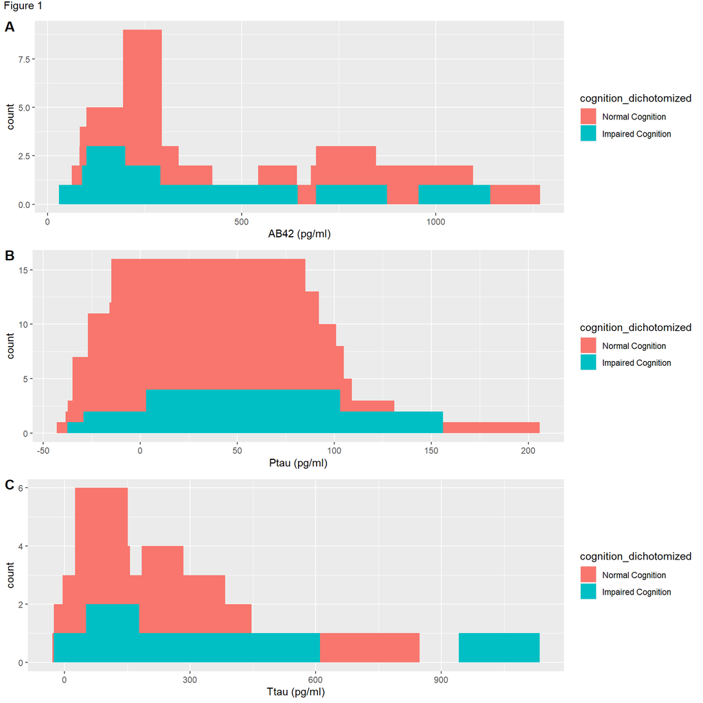

```r
#Using ggplot to create histograms of each biomarker that are filled by "cognition_dichotomized"

h1 <- ggplot(nyu.clean, aes(x = AB42, y = ..count.., fill = cognition_dichotomized)) +geom_bar(width = 100) + xlab("AB42 (pg/ml)")
h2 <- ggplot(nyu.clean, aes(x = Ptau, y = ..count.., fill = cognition_dichotomized)) +geom_bar(width = 100) + xlab("Ptau (pg/ml)")
h3 <- ggplot(nyu.clean, aes(x = Ttau, y = ..count.., fill = cognition_dichotomized)) +geom_bar(width = 100) + xlab("Ttau (pg/ml)")

#The library 'ggpubr' has functions "annotate_figure" and "ggarrange". "annotate_figure" is used to label the figure as "Figure 1", note "top" is used to add a label at the top, but I left it as "" becuase it helped format the data. ggarrange is used to return all figures on one page (number on each row/column is psecified) and label A,B,C.

annotate_figure(ggarrange(h1, h2, h3, labels = c("A", "B", "C"), ncol = 1, nrow = 3),fig.lab = "Figure 1", top ="" )
```

Apparent right skew for all biomarkers.

To view skew numerically.

```r
#Storing stat.desc return for AB42, Ptau, and Ttau in variable skew and then calling only skewness in the next line.

skew <- sapply(nyu.clean[,11:13],stat.desc,norm = T)
skew["skewness",1:3]
```

```
##      AB42      Ptau      Ttau
## 0.6274342 1.5636929 1.8500222
```

Skewness agrees with visual interpretation.

# Mean Analysis

First Looking as the mean across amyloid-beta, phosphorylated tau, and total tau

```r
#Using the sapply funtion to apply the mean function to columns AB42, Ptau, and Ttau.

sapply(nyu.clean[,11:13], mean)
```

```
##      AB42      Ptau      Ttau
## 441.72158  38.20671 181.10475
```

To see if the means vary based on follow up diagnosis, I investigated each biomarker’s average by cognitive diagnosis of the follow up visit.

```r
#Running a for loop of values 11, 12, and 13 which corresponds to columns AB42, Ptau, and Ttau. The for loop first prints a solid line to help with the visualization, then prints the name of the biomarker being analyzed, then the means by cognitive diagnosis.

for (i in 11:13) {
  print('__________________________________________________________________________________________')
  print(names(nyu.clean[i]))
  print(by(nyu.clean[,i], nyu.clean$Last_dx_group, mean))
  print('__________________________________________________________________________________________')
  print('')
  print('')
}
```

```
## [1] "__________________________________________________________________________________________"
## [1] "AB42"
## nyu.clean$Last_dx_group: Normal Cognition
## [1] 460.4966
## ------------------------------------------------------------
## nyu.clean$Last_dx_group: Mild Cognitive Impairment
## [1] 327.0195
## ------------------------------------------------------------
## nyu.clean$Last_dx_group: Alzheimer’s Disease
## [1] 240.7667
## [1] "__________________________________________________________________________________________"
## [1] ""
## [1] ""
## [1] "__________________________________________________________________________________________"
## [1] "Ptau"
## nyu.clean$Last_dx_group: Normal Cognition
## [1] 38.07045
## ------------------------------------------------------------
## nyu.clean$Last_dx_group: Mild Cognitive Impairment
## [1] 38.79123
## ------------------------------------------------------------
## nyu.clean$Last_dx_group: Alzheimer’s Disease
## [1] 40.3381
## [1] "__________________________________________________________________________________________"
## [1] ""
## [1] ""
## [1] "__________________________________________________________________________________________"
## [1] "Ttau"
## nyu.clean$Last_dx_group: Normal Cognition
## [1] 182.6067
## ------------------------------------------------------------
## nyu.clean$Last_dx_group: Mild Cognitive Impairment
## [1] 165.4653
## ------------------------------------------------------------
## nyu.clean$Last_dx_group: Alzheimer’s Disease
## [1] 182.5733
## [1] "__________________________________________________________________________________________"
## [1] ""
## [1] ""
```

# Visualization of Mean

I then wanted to visualize the means in bar graphs.

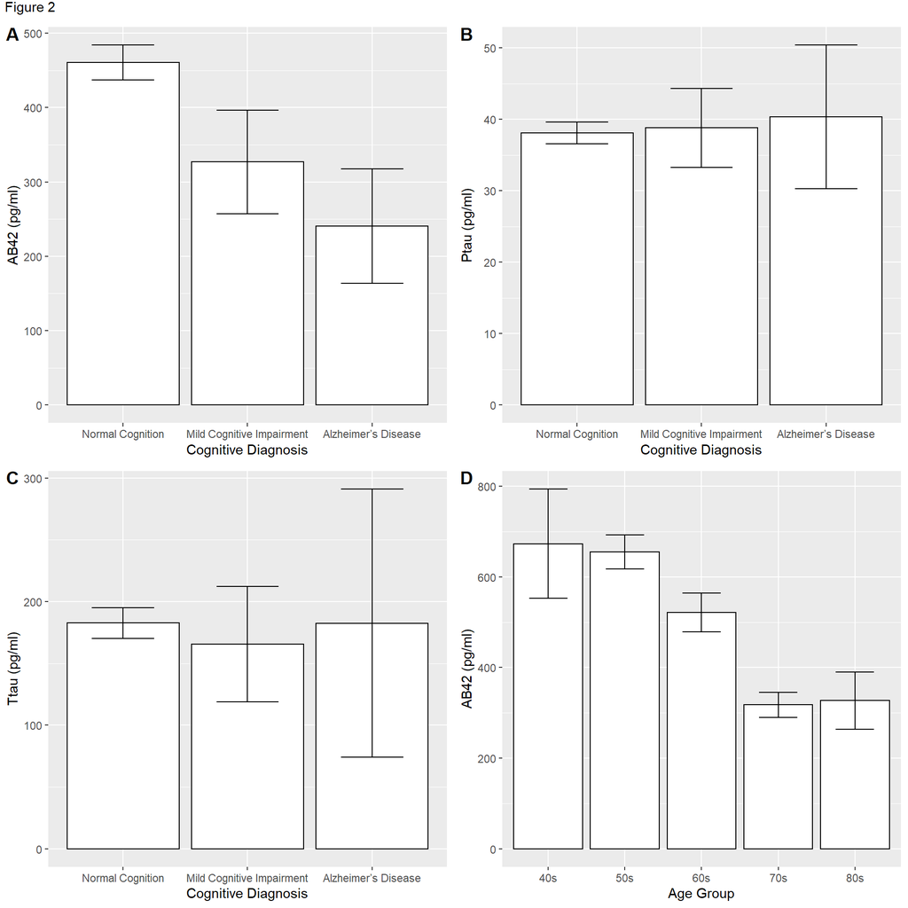

```r
#Using ggplot to create and label bar graphs of each biomarker by cognitive diagnosis and storing them in variables.

p1 <- ggplot(nyu.clean, aes(x = Last_dx_group, y = AB42)) + stat_summary(fun = mean, geom="bar",fill = "white", color = "black") + stat_summary(fun.data = mean_cl_normal, geom = "errorbar", width = .5) + xlab("Cognitive Diagnosis") + ylab("AB42 (pg/ml)")
p2 <- ggplot(nyu.clean, aes(x = Last_dx_group, y = Ptau)) + stat_summary(fun = mean, geom="bar",fill = "white", color = "black") + stat_summary(fun.data = mean_cl_normal, geom = "errorbar", width = .5) + xlab("Cognitive Diagnosis") + ylab("Ptau (pg/ml)")
p3 <- ggplot(nyu.clean, aes(x = Last_dx_group, y = Ttau)) + stat_summary(fun = mean, geom="bar",fill = "white", color = "black") + stat_summary(fun.data = mean_cl_normal, geom = "errorbar", width = .5) + xlab("Cognitive Diagnosis") + ylab("Ttau (pg/ml)")

#Based on trends in seen by plotting AB42 by cognitive diagnosis, I then decided to plot AB42 by "Age_gorup".

p4 <- ggplot(nyu.clean, aes(x = age_group, y = AB42)) + stat_summary(fun = mean, geom="bar",fill = "white", color = "black") + stat_summary(fun.data = mean_cl_normal, geom = "errorbar", width = .5) + xlab("Age Group") + ylab("AB42 (pg/ml)")

#Library 'ggpubr' functions to put ggplots in one pane and label the figure (see slide 7 for more details).

annotate_figure(ggarrange(p1, p2, p3, p4, labels = c("A", "B", "C", "D"), ncol = 2, nrow = 2, align = 'hv'),fig.lab = "Figure 2", top ="" )
```

# Linear Regression of AB42

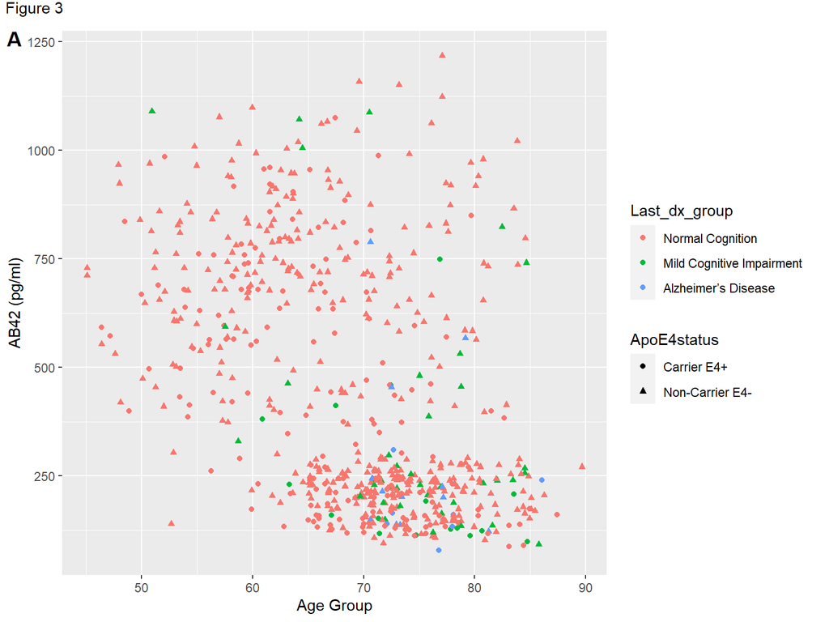

```r
#Using ggplot to plot scatter plots of AB42 by age and coloring them by cognitive diagnosis or APOE4 status

s1 <- ggplot(nyu.clean, aes(x = age, y = AB42, col = Last_dx_group, shape = ApoE4status)) + geom_point() + xlab("Age Group") + ylab("AB42 (pg/ml)")

#Library 'ggpubr' functions to put ggplots in one pane and label the figure (see slide 7 for more details).

annotate_figure(ggarrange(s1, labels = "A", ncol = 1, nrow = 1, align = 'hv'),fig.lab = "Figure 3", top ="" )
```

```r
#The subsequent linear regression model was using APOE4 - for the model, however I wanted APOE e4 +. The following code relevels the factors.

nyu.clean <- within(nyu.clean, ApoE4status <- relevel(ApoE4status, ref = 2))

#Running a linear regression models on AB42 by age and age/APOE4 status.

AB42_LM <- lm(AB42 ~ age, data = nyu.clean)
AB42_LM2 <- lm(AB42 ~ age + ApoE4status, data = nyu.clean)

#Using the AIC function to determine which model has a better fit

AIC(AB42_LM,AB42_LM2)
```

```
##          df      AIC
## AB42_LM   3 9063.485
## AB42_LM2  4 9049.047
```

```r
#Because the second model has a slightly better fit, the summary was run for that model.

summary(AB42_LM2)
```

```
##
## Call:
## lm(formula = AB42 ~ age + ApoE4status, data = nyu.clean)
##
## Residuals:
##     Min      1Q  Median      3Q     Max
## -575.26 -188.02  -80.11  172.02  872.13
##
## Coefficients:
##                        Estimate Std. Error t value Pr(>|t|)
## (Intercept)            1509.916     77.938  19.373  < 2e-16 ***
## age                     -15.102      1.109 -13.615  < 2e-16 ***
## ApoE4statusCarrier E4+  -88.000     21.618  -4.071 5.27e-05 ***
## ---
## Signif. codes:  0 '***' 0.001 '**' 0.01 '*' 0.05 '.' 0.1 ' ' 1
##
## Residual standard error: 251.5 on 648 degrees of freedom
## Multiple R-squared:  0.2307, Adjusted R-squared:  0.2283
## F-statistic: 97.16 on 2 and 648 DF,  p-value: < 2.2e-16
```

- Combined model is a very slightly better fit.
- F-statistic gives confidence that the model is better than none.
- R squared value is 0.2307.
- Increase in age results in a decrease in AB42.
- A switch from APOE4 negative to positive results in a large decrease in AB42.

# Discussion and Future Directions

**Discussion**

- Within this analysis, no clear trend in predictive value of tau.
- A lower AB42 concentration appears have a correlation with cognitive decline.
- The linear regression model shows a weak correlation with age and APOE4 status on AB42 concentration.

**Future Directions**

- To run more non-parametric analysis (ex. Mann-Whitney test) of variables because of observed skew in each biomarker.
- To investigate if gender had any observable trends.
- To see if subsetting the data by APOE4 status would have changed the distribution of data.
- The study was over 90% caucasian, so a more diverse study would be more representative.
- Collecting biomarker values after second clinical visit to analyze changes in concentration.

# References

- de Leon MJ, Pirraglia E, Osorio RS, Glodzik L, Saint-Louis L, Kim H-J, et al. (2018) The nonlinear relationship between cerebrospinal fluid Aβ42 and tau in preclinical Alzheimer’s disease. PLoS ONE 13(2): e0191240. https://doi.org/10.1371/journal.pone.0191240